# RT01: Uso do pacote `ggplot2`

Estudo dirigido e Relatórios Técnicos em R Markdown.

Lucas Henrique Nogueira

2024-06-09

# Introdução

## O pacote `ggplot2`

$~~$ O pacote `ggplot2` é uma das bibliotecas mais populares para visualização de dados no R. Desenvolvido por Hadley Wickham, ele implementa a abordagem de gramática de gráficos (*grammar of graphics*), permitindo a criação de visualizações complexas de maneira concisa e flexível.

### Principais Características do `ggplot2`

- **Gramática de Gráficos**: Baseia-se na gramática de gráficos, que permite a construção incremental de gráficos por meio da adição de camadas de componentes, como dados, geometrias, estatísticas, escalas, coordenadas e facetas.
- **Abordagem Declarativa**: Em vez de especificar passo a passo como um gráfico deve ser desenhado, descreve-se a relação entre dados e as representações visuais.
- **Suporte a Diversos Tipos de Gráficos**: Suporta uma ampla variedade de gráficos, incluindo gráficos de dispersão, linhas, barras, boxplots, histogramas, gráficos de densidade, entre outros.
- **Flexibilidade e Extensibilidade**: Permite criar gráficos simples ou altamente customizados com facilidade. Integra-se bem com outros pacotes do ecossistema tidyverse.

## Conjunto de dados `gapminder`

$~~$ O conjunto de dados `gapminder` é amplamente utilizado para ilustrar a evolução de diversos indicadores socioeconômicos e de saúde ao longo do tempo. Este conjunto de dados contém informações sobre a expectativa de vida, PIB per capita, e população de vários países do mundo em diferentes anos, facilitando análises de tendências e comparações entre nações.

### Estrutura do Conjunto de Dados

O conjunto de dados `gapminder` possui as seguintes colunas principais:

- **country**: O nome do país.
- **continent**: O continente ao qual o país pertence.
- **year**: O ano de registro dos dados.
- **lifeExp**: Expectativa de vida ao nascer (em anos).
- **pop**: População total do país.
- **gdpPercap**: PIB per capita (Produto Interno Bruto per capita).

## Conjunto de dados `mtcars`

$~~$ O conjunto de dados `mtcars` é um conjunto de dados integrado no R, derivado da revista Motor Trend US de 1974. Ele contém dados sobre o consumo de combustível e outras 10 características de design e desempenho de 32 carros. Este conjunto de dados é amplamente utilizado para ensinar técnicas de análise de dados e visualização em R.

### Estrutura do Conjunto de Dados

O `mtcars` possui 32 observações (carros) e 11 variáveis. As variáveis são:

- `mpg` (Milhas por Galão): Consumo de combustível.
- `cyl` (Número de Cilindros): Número de cilindros no motor.
- `disp` (Deslocamento): Volume do motor (polegadas cúbicas).
- `hp` (Potência): Potência do motor (cavalos de potência).
- `drat` (Relação do Eixo Traseiro): Relação do eixo traseiro.
- `wt` (Peso): Peso do carro (em milhares de libras).
- `qsec` (Tempo de 1/4 de Milha): Tempo para percorrer 1/4 de milha (em segundos).
- `vs` (Forma do Motor): Tipo de motor (0 = em V, 1 = reto).
- `am` (Transmissão): Tipo de transmissão (0 = automática, 1 = manual).
- `gear` (Número de Marchas): Número de marchas.
- `carb` (Número de Carburação): Número de carburadores.

## Conjunto de dados `diamonds`

$~~$ O conjunto de dados `diamonds` é um dos datasets incluídos no pacote `ggplot2` e é amplamente utilizado para demonstrações de visualização de dados. Este dataset contém informações sobre 53.940 diamantes, incluindo várias características que influenciam o preço dos diamantes.

### Estrutura do Conjunto de Dados

O conjunto de dados `diamonds` possui as seguintes variáveis:

- **carat**: Peso do diamante (em quilates).
- **cut**: Qualidade do corte do diamante (Fair, Good, Very Good, Premium, Ideal).
- **color**: Cor do diamante, de J (pior) a D (melhor).
- **clarity**: Clareza do diamante, com categorias de I1 (pior) a IF (melhor).
- **depth**: Profundidade total do diamante como uma porcentagem da média do diâmetro.
- **table**: Largura da parte superior do diamante em relação à maior parte do diâmetro.
- **price**: Preço do diamante (em dólares).
- **x**: Comprimento do diamante (em milímetros).
- **y**: Largura do diamante (em milímetros).
- **z**: Profundidade do diamante (em milímetros).

# Realização dos exercícios propostos

## Questão 1 - Adicionando texto a gráfico

$~~$ Proposta: Adicionar texto a um gráfico criado com o pacote `ggplot2` em R com a utilização do conjunto de dados `gapminder`.

```r
  library(gapminder);  library(ggplot2)
```

### Gráfico

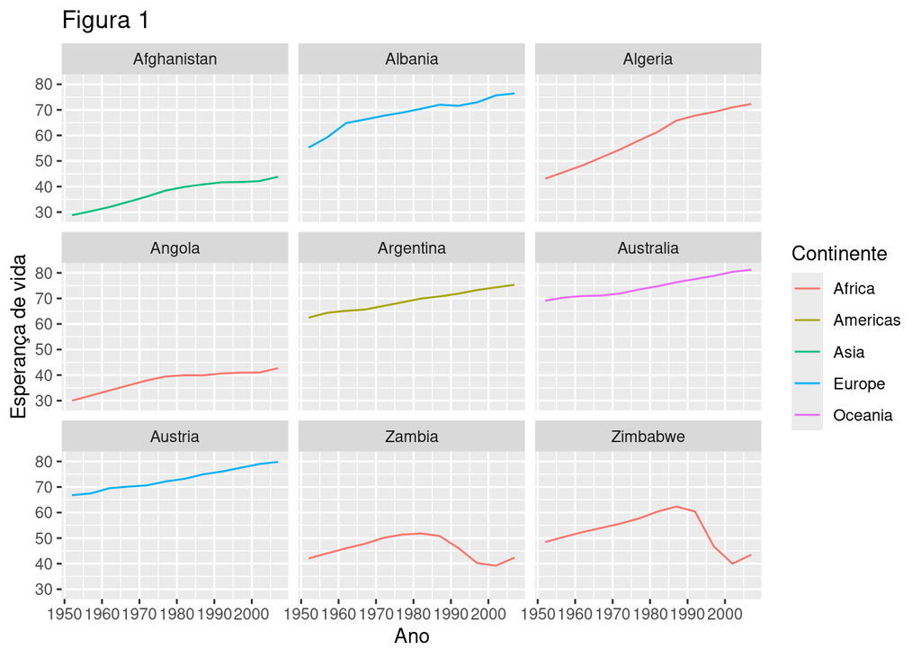

### Script do gráfico

```r
  comeca.com <- substr(gapminder$country, start = 1, stop = 1)
  paises.az <- gapminder[comeca.com %in% c("A", "Z"), ]

  ggplot(data = paises.az, aes(x = year, y = lifeExp, color = continent)) +
   geom_line() + facet_wrap( ~ country) + ggtitle("Figura 1")+ xlab("Ano") +
   ylab("Esperança de vida") + scale_colour_discrete(name = "Continente")
```

## Questão 2 - Diagrama de dispersão

$~~$ Proposta: Criar um diagrama de dispersão com o conjunto de dados `mtcars` e o pacote `ggplot2`.

```r
  data(mtcars)
```

### Gráfico

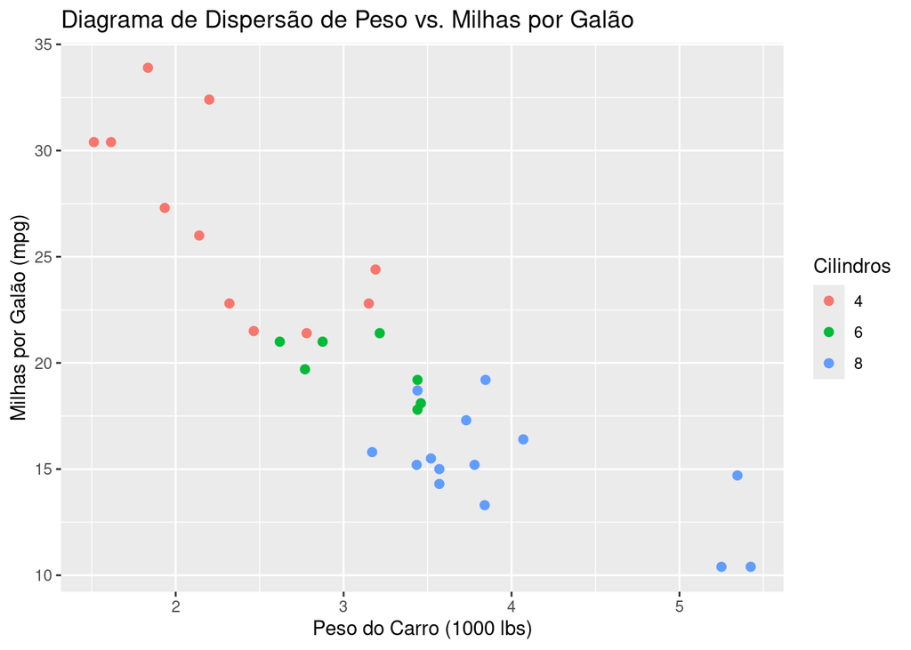

### Script do gráfico

```r
  mtcars$cyl <- factor(mtcars$cyl)

  ggplot(mtcars, aes(x = wt, y = mpg, color = cyl)) +
  geom_point(size = 2) +
  labs(title = "Diagrama de Dispersão de Peso vs. Milhas por Galão",
       x = "Peso do Carro (1000 lbs)",
       y = "Milhas por Galão (mpg)",
       color = "Cilindros")
```

## Questão 3 - Formatos dos símbolos dos dados

$~~$ Proposta: Criar um novo diagrama de dispersão com os dados do exercício anterior, usando formatos diferentes de símbolos para distinguir as diversas quantidades de cilindros do motor.

### Gráfico

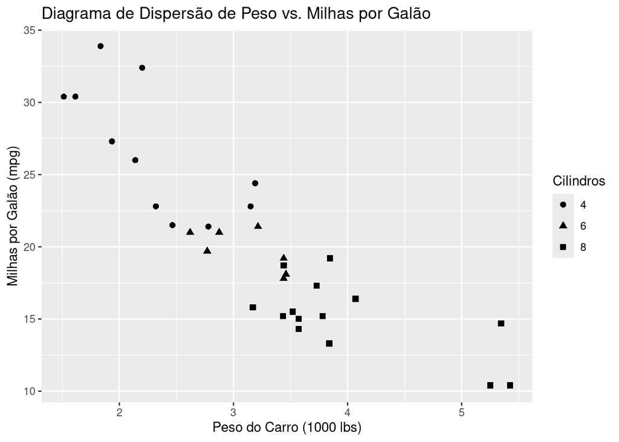

### Script do gráfico

```r
  ggplot(mtcars, aes(x = wt, y = mpg, shape = cyl)) +
    geom_point(size = 2) +
    labs(title = "Diagrama de Dispersão de Peso vs. Milhas por Galão",
       x = "Peso do Carro (1000 lbs)",
       y = "Milhas por Galão (mpg)",
       shape = "Cilindros")
```

## Questão 4 - Atribuindo função `ggplot2` a objeto

$~~$ Proposta: Criar um diagrama de dispersão do conjunto de dados `diamonds`, atribuindo a função ggplot a um objeto.

```r
  data(diamonds)
```

### Gráfico

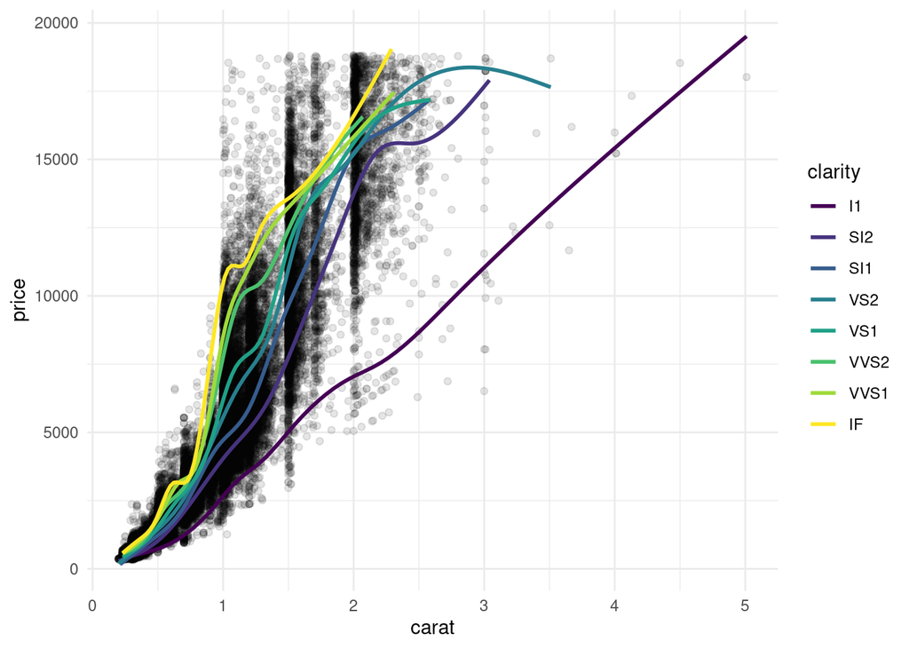

### Script do gráfico

```r
  meu.grafico <- ggplot(diamonds, aes(x = carat, y = price)) +
  geom_point(alpha = 0.1) +
  geom_smooth(aes(color = clarity), se = FALSE) + theme_minimal()

  # OBS: Estava aparecendo a seguinte mensagem ao exibir o gráfico:
  # ‘geom_smooth()‘ using method = ’gam’ and formula = ’y ~ s(x, bs = "cs")’
  # Por isso utilizei a função `suppressMessages(print())`
  suppressMessages(print(meu.grafico))
```

## Questão 5 - Criando gráfico de área

$~~$ Proposta: Criar gráficos de densidade da renda per capita, preenchidos com cores de acordo com o continente através do conjunto de dados `gapminder` e do pacote `ggplot2`.

### Gráfico

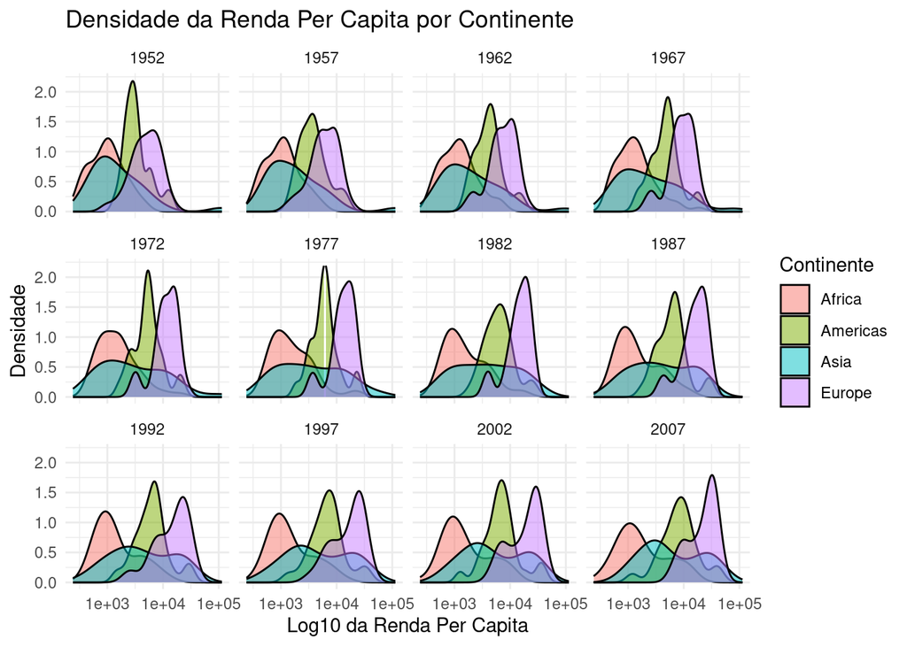

### Script do gráfico

```r
  # Removendo o continente da Oceania
  gapminder_filtered <- gapminder[gapminder$continent != "Oceania", ]

  ggplot(gapminder_filtered, aes(x = gdpPercap, fill = continent)) +
    geom_density(alpha = 0.5) + facet_wrap(~ year, nrow = 3, ncol = 4) +
    labs(title = "Densidade da Renda Per Capita por Continente",
    x = "Log10 da Renda Per Capita",
    y = "Densidade", fill = "Continente") + scale_x_log10() +
    scale_y_continuous(limits = c(0, 2.2)) +
    theme_minimal()
```

# Considerações finais

$~~$O pacote `ggplot2` é uma ferramenta versátil e robusta para visualização de dados no ambiente R. Com sua ampla gama de funcionalidades, é possível criar uma variedade de gráficos com uma sintaxe simples e intuitiva, simplificando assim a análise e a tendências nos dados.

$~~$Ao longo das questões fornecidas, foi possível explorar várias funcionalidades do `ggplot2` e dos conjuntos de dados `gapminder`, `mtcars` e `diamonds`. Esses conjuntos de dados forneceram uma base sólida para a criação de gráficos informativos e aprofundados, permitindo explorar diferentes aspectos dos dados e extrair insights valiosos para análises.

# Links

- **[Documentação do pacote `ggplot2`](https://ggplot2.tidyverse.org/)**
- **[Documentação do conjunto de dados `gapminder`](https://www.rdocumentation.org/packages/gapminder/versions/0.3.0)**
- **[Documentação do conjunto de dados `mtcars`](https://www.rdocumentation.org/packages/datasets/versions/3.6.2/topics/mtcars)**
- **[Documentação do conjunto de dados `diamonds`](https://ggplot2.tidyverse.org/reference/diamonds.html)**